# Final Project

## Graphical Data Exploration

### scatterplot( )

Scatterplot: Using the ginkgo data, reate a scatterplot of max leaf depth (x) and max leaf width (y). You can personalize your plot with the following commands:

- col: defines color of the plots in the scatterplot.
- pch: defines the point symbols in the functions plot() and lines(). The pch stands for plot character. The pch contains numeric values rangers from 0 to 25 or character symbols (“+”, “.”, “;”, etc.) specifying in symbols (or shapes).
- cex: defines a number indicating the amount by which plotting text and symbols should be scaled relative to the default.
- main: defines the title of the plot
- xlab: defines the name of the x axis in the plot
- ylab: defines the name of the y axis in the plot
- xlim: defines the limits of the scale in the x axis
- ylim: defines the limits of the scale in the y axis

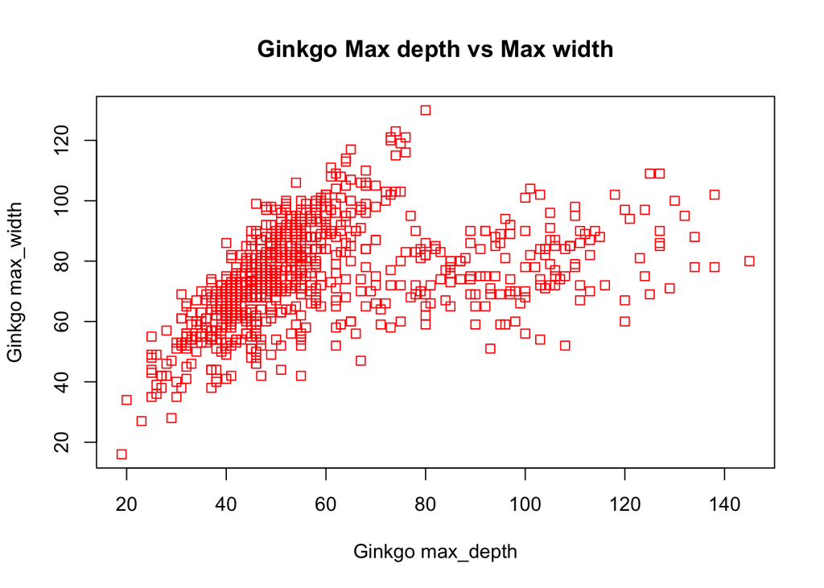

```r
#Let's plot the maximum depth and width of the ginkgo data frame
plot(ginkgo$max_depth, ginkgo$max_width,
     col="red",
     pch=0, #2 stands for squares
     cex=1, #we won't increase the size for better observation of the plots
     main="Ginkgo Max depth vs Max width",
     xlab="Ginkgo max_depth",
     ylab="Ginkgo max_width",
     # xlimit=c(0,160), (we won't include it because of the warnings to be displayed)
     # ylimit=c(0,140) (we won't include it because of the warnings to be displayed)
     )
```

### hist( )

The generic function hist computes a histogram of the given data values. If plot = TRUE, the resulting object of class “histogram” is plotted by plot.histogram, before it is returned.

You can personalize your plot with the following commands: * breaks: a single number giving the number of cells for the histogram.

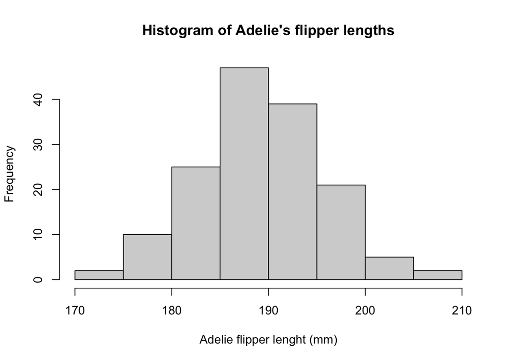

```r
#Let's make a histogram of the penguin Adelie flipper lengths from the palmerpenguins data
hist(dat_adelie$flipper_length_mm,
     breaks=8,
     main="Histogram of Adelie's flipper lengths",
     xlab="Adelie flipper lenght (mm)")
```

### boxplot( )

In R, boxplot (and whisker plot) is created using the boxplot() function. The boxplot() function takes in any number of numeric vectors, drawing a boxplot for each vector.

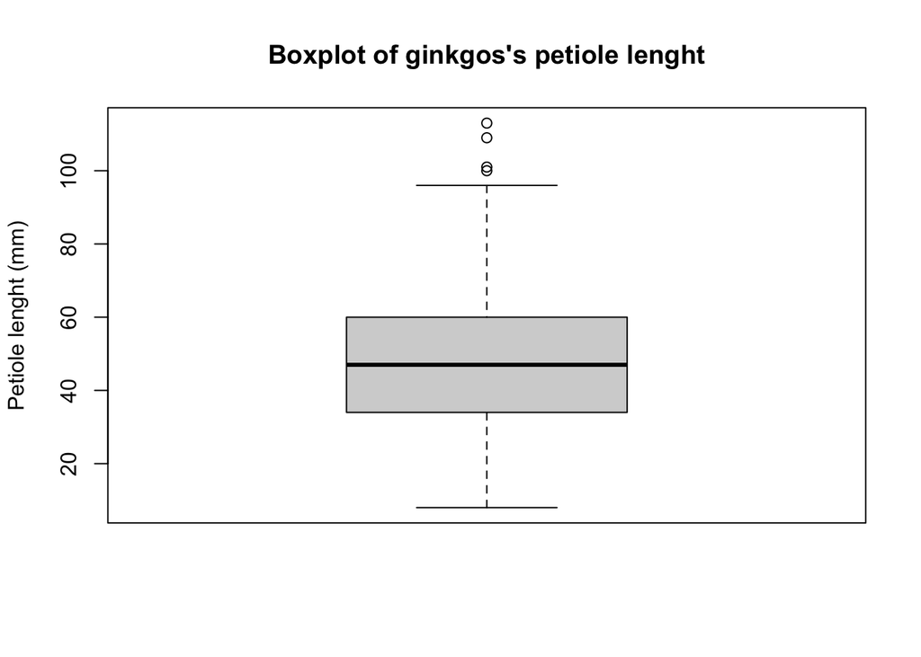

```r
#To create a boxplot we can use:
boxplot(ginkgo$petiole_length,
        main="Boxplot of ginkgos's petiole lenght",
        ylab="Petiole lenght (mm)")
```

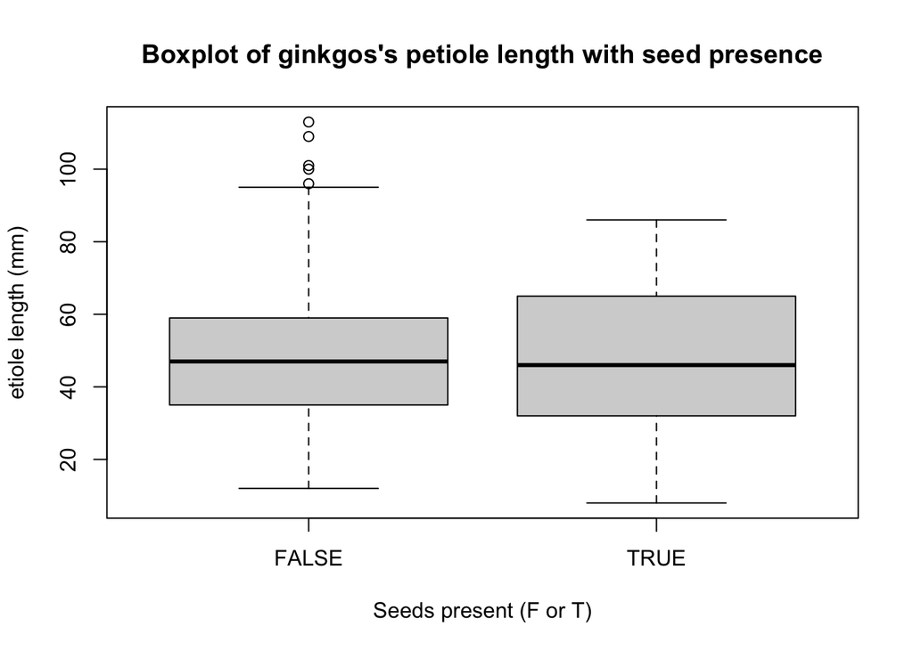

```r
#To create a conditional boxplot we can use:
boxplot(ginkgo$petiole_length~ginkgo$seeds_present,
        main="Boxplot of ginkgos's petiole length with seed presence",
        xlab="Seeds present (F or T)",
        ylab="etiole length (mm)")
```